# Credit Risc Scorecard

Iryna Bazaka and Mikołaj Ostrzołek

6/25/2018

## Data preparation

At the begeninng we have to load necessary libraries.

```r
library(readr)
library(data.table)
```

Then we will load the data and check their structure.

```r
credit <- read.csv("project_data.csv")
str(credit)
```

```
## 'data.frame':    1000 obs. of  17 variables:
##  $ checking_balance    : Factor w/ 4 levels "< 0 DM","> 200 DM",..: 1 3 4 1 1 4 4 3 4 3 ...
##  $ months_loan_duration: int  6 48 12 42 24 36 24 36 12 30 ...
##  $ credit_history      : Factor w/ 5 levels "critical","good",..: 1 2 1 2 4 2 2 2 2 1 ...
##  $ purpose             : Factor w/ 6 levels "business","car",..: 5 5 4 5 2 4 5 2 5 2 ...
##  $ amount              : int  1169 5951 2096 7882 4870 9055 2835 6948 3059 5234 ...
##  $ savings_balance     : Factor w/ 5 levels "< 100 DM","> 1000 DM",..: 5 1 1 1 1 5 4 1 2 1 ...
##  $ employment_duration : Factor w/ 5 levels "< 1 year","> 7 years",..: 2 3 4 4 3 3 2 3 4 5 ...
##  $ percent_of_income   : int  4 2 2 2 3 2 3 2 2 4 ...
##  $ years_at_residence  : int  4 2 3 4 4 4 4 2 4 2 ...
##  $ age                 : int  67 22 49 45 53 35 53 35 61 28 ...
##  $ other_credit        : Factor w/ 3 levels "bank","none",..: 2 2 2 2 2 2 2 2 2 2 ...
##  $ housing             : Factor w/ 3 levels "other","own",..: 2 2 2 1 1 1 2 3 2 2 ...
##  $ existing_loans_count: int  2 1 1 1 2 1 1 1 1 2 ...
##  $ job                 : Factor w/ 4 levels "management","skilled",..: 2 2 4 2 2 4 2 1 4 1 ...
##  $ dependents          : int  1 1 2 2 2 2 1 1 1 1 ...
##  $ phone               : Factor w/ 2 levels "no","yes": 2 1 1 1 1 2 1 2 1 1 ...
##  $ default             : Factor w/ 2 levels "no","yes": 1 2 1 1 2 1 1 1 1 2 ...
```

```r
dim(credit)
```

```
## [1] 1000   17
```

```r
summary(credit)
```

```
##    checking_balance months_loan_duration   credit_history
##  < 0 DM    :274     Min.   : 4.0         critical :293
##  > 200 DM  : 63     1st Qu.:12.0         good     :530
##  1 - 200 DM:269     Median :18.0         perfect  : 40
##  unknown   :394     Mean   :20.9         poor     : 88
##                     3rd Qu.:24.0         very good: 49
##                     Max.   :72.0
##                  purpose        amount           savings_balance
##  business            : 97   Min.   :  250   < 100 DM     :603
##  car                 :337   1st Qu.: 1366   > 1000 DM    : 48
##  car0                : 12   Median : 2320   100 - 500 DM :103
##  education           : 59   Mean   : 3271   500 - 1000 DM: 63
##  furniture/appliances:473   3rd Qu.: 3972   unknown      :183
##  renovations         : 22   Max.   :18424
##   employment_duration percent_of_income years_at_residence      age
##  < 1 year   :172      Min.   :1.000     Min.   :1.000      Min.   :19.00
##  > 7 years  :253      1st Qu.:2.000     1st Qu.:2.000      1st Qu.:27.00
##  1 - 4 years:339      Median :3.000     Median :3.000      Median :33.00
##  4 - 7 years:174      Mean   :2.973     Mean   :2.845      Mean   :35.55
##  unemployed : 62      3rd Qu.:4.000     3rd Qu.:4.000      3rd Qu.:42.00
##                       Max.   :4.000     Max.   :4.000      Max.   :75.00
##  other_credit  housing    existing_loans_count         job
##  bank :139    other:108   Min.   :1.000        management:148
##  none :814    own  :713   1st Qu.:1.000        skilled   :630
##  store: 47    rent :179   Median :1.000        unemployed: 22
##                           Mean   :1.407        unskilled :200
##                           3rd Qu.:2.000
##                           Max.   :4.000
##    dependents    phone     default
##  Min.   :1.000   no :596   no :700
##  1st Qu.:1.000   yes:404   yes:300
##  Median :1.000
##  Mean   :1.155
##  3rd Qu.:1.000
##  Max.   :2.000
```

```r
sum(is.na(credit))
```

```
## [1] 0
```

Next we have to change raw data into numeric and dactory types.

```r
credit$months_loan_duration <- as.numeric(credit$months_loan_duration)
credit$amount <- as.numeric(credit$amount)
credit$percent_of_income <- as.numeric(credit$percent_of_income)
credit$years_at_residence <- as.numeric(credit$years_at_residence)
credit$age <- as.numeric(credit$age)
credit$existing_loans_count <- as.numeric(credit$existing_loans_count)
credit$dependents <- as.numeric(credit$dependents)
```

```r
credit$checking_balance <- as.factor(credit$checking_balance)
credit$credit_history <- as.factor(credit$credit_history)
credit$purpose <- as.factor(credit$purpose)
credit$other_credit <- as.factor(credit$other_credit)
credit$savings_balance <- as.factor(credit$savings_balance)
credit$employment_duration <- as.factor(credit$employment_duration)
credit$housing <- as.factor(credit$housing)
credit$job <- as.factor(credit$job)
credit$phone <- as.factor(credit$phone)
```

Now we can check the results.

```r
summary(credit)
```

```
##    checking_balance months_loan_duration   credit_history
##  < 0 DM    :274     Min.   : 4.0         critical :293
##  > 200 DM  : 63     1st Qu.:12.0         good     :530
##  1 - 200 DM:269     Median :18.0         perfect  : 40
##  unknown   :394     Mean   :20.9         poor     : 88
##                     3rd Qu.:24.0         very good: 49
##                     Max.   :72.0
##                  purpose        amount           savings_balance
##  business            : 97   Min.   :  250   < 100 DM     :603
##  car                 :337   1st Qu.: 1366   > 1000 DM    : 48
##  car0                : 12   Median : 2320   100 - 500 DM :103
##  education           : 59   Mean   : 3271   500 - 1000 DM: 63
##  furniture/appliances:473   3rd Qu.: 3972   unknown      :183
##  renovations         : 22   Max.   :18424
##   employment_duration percent_of_income years_at_residence      age
##  < 1 year   :172      Min.   :1.000     Min.   :1.000      Min.   :19.00
##  > 7 years  :253      1st Qu.:2.000     1st Qu.:2.000      1st Qu.:27.00
##  1 - 4 years:339      Median :3.000     Median :3.000      Median :33.00
##  4 - 7 years:174      Mean   :2.973     Mean   :2.845      Mean   :35.55
##  unemployed : 62      3rd Qu.:4.000     3rd Qu.:4.000      3rd Qu.:42.00
##                       Max.   :4.000     Max.   :4.000      Max.   :75.00
##  other_credit  housing    existing_loans_count         job
##  bank :139    other:108   Min.   :1.000        management:148
##  none :814    own  :713   1st Qu.:1.000        skilled   :630
##  store: 47    rent :179   Median :1.000        unemployed: 22
##                           Mean   :1.407        unskilled :200
##                           3rd Qu.:2.000
##                           Max.   :4.000
##    dependents    phone     default
##  Min.   :1.000   no :596   no :700
##  1st Qu.:1.000   yes:404   yes:300
##  Median :1.000
##  Mean   :1.155
##  3rd Qu.:1.000
##  Max.   :2.000
```

```r
str(credit)
```

```
## 'data.frame':    1000 obs. of  17 variables:
##  $ checking_balance    : Factor w/ 4 levels "< 0 DM","> 200 DM",..: 1 3 4 1 1 4 4 3 4 3 ...
##  $ months_loan_duration: num  6 48 12 42 24 36 24 36 12 30 ...
##  $ credit_history      : Factor w/ 5 levels "critical","good",..: 1 2 1 2 4 2 2 2 2 1 ...
##  $ purpose             : Factor w/ 6 levels "business","car",..: 5 5 4 5 2 4 5 2 5 2 ...
##  $ amount              : num  1169 5951 2096 7882 4870 ...
##  $ savings_balance     : Factor w/ 5 levels "< 100 DM","> 1000 DM",..: 5 1 1 1 1 5 4 1 2 1 ...
##  $ employment_duration : Factor w/ 5 levels "< 1 year","> 7 years",..: 2 3 4 4 3 3 2 3 4 5 ...
##  $ percent_of_income   : num  4 2 2 2 3 2 3 2 2 4 ...
##  $ years_at_residence  : num  4 2 3 4 4 4 4 2 4 2 ...
##  $ age                 : num  67 22 49 45 53 35 53 35 61 28 ...
##  $ other_credit        : Factor w/ 3 levels "bank","none",..: 2 2 2 2 2 2 2 2 2 2 ...
##  $ housing             : Factor w/ 3 levels "other","own",..: 2 2 2 1 1 1 2 3 2 2 ...
##  $ existing_loans_count: num  2 1 1 1 2 1 1 1 1 2 ...
##  $ job                 : Factor w/ 4 levels "management","skilled",..: 2 2 4 2 2 4 2 1 4 1 ...
##  $ dependents          : num  1 1 2 2 2 2 1 1 1 1 ...
##  $ phone               : Factor w/ 2 levels "no","yes": 2 1 1 1 1 2 1 2 1 1 ...
##  $ default             : Factor w/ 2 levels "no","yes": 1 2 1 1 2 1 1 1 1 2 ...
```

## Exploratory Data Analysis

### Fine Classing

In this section we will create subgroups and calculate Weight of Evidence (WOE) and Information Value(IV) of the variable based on WOE’s and IV’s of subgroups respectively.

### Data factorization

We will start from dividing our set to two subsets, one containig factor variables and the other containing numeric ones.

```r
colnames(credit)
```

```
##  [1] "checking_balance"     "months_loan_duration" "credit_history"
##  [4] "purpose"              "amount"               "savings_balance"
##  [7] "employment_duration"  "percent_of_income"    "years_at_residence"
## [10] "age"                  "other_credit"         "housing"
## [13] "existing_loans_count" "job"                  "dependents"
## [16] "phone"                "default"
```

```r
columns <- c("checking_balance", "months_loan_duration", "credit_history", "purpose", "amount", "savings_balance", "employment_duration",
             "percent_of_income", "years_at_residence", "age", "other_credit", "housing",
             "existing_loans_count", "job", "dependents", "phone")

base <- credit[,columns]
nums <- sapply(base, is.numeric)
base.n <- base[,nums]

fact <- sapply(base, is.factor)
base.f <- base[,fact]

percentile<-apply(X=base.n, MARGIN=2, FUN=function(x) round(quantile(x, seq(0.1,1,0.1), na.rm=TRUE),2))
```

It may happen that numeric variable can be in fact factorised, due to having small number of unique values.

```r
unique<-apply(base.n, MARGIN=2, function(x) length(unique(x)))
```

We will treat variable as a numeric one if it has at least 10 unique values.

```r
numeric<-colnames(base.n[which(unique>=10)])
```

If variable has less than 10 uniqe values or was previously classified as a factor one, it will be placed in factor set.

```r
num_as_fact<-colnames(base.n[which(unique<10 & unique>1 )])
```

```r
options(scipen=999)
```

```r
for (m in numeric){
  base.n[,paste(m,"_fine", sep="")]<-cut(
    x=as.matrix(base.n[m]),
    breaks=c(-Inf,unique(percentile[,m])),
    labels =c(paste("<=",unique(percentile[,m])))
  )
}
```

```r
fact<-cbind(base.f, base.n[,num_as_fact])
fact[,num_as_fact]<-lapply(fact[,num_as_fact],as.factor)
```

### Weight of Evidence calculation using smbinning

Due to the fact, that in `smbinning` “0” means bad we will revert the definition of gb flag.

```r
base.n$def_woe<-as.numeric(credit$default)-1
base.n$def<- 1-base.n$def_woe
```

Now we will create list for WOEs

```r
WOE<-list()
```

And data frame for Information value.

```r
IV<-data.frame(VAR=character(), IV=integer())
```

```r
base.n_fine<-base.n[ ,grepl(pattern="_fine" , x=names(base.n))]
```

```r
library(smbinning)
```

## Basic descriptive statistics

Using `smbining` we can inspect basic statistics.

```r
smbinning.eda(base.n, rounding = 3, pbar = FALSE)
```

```
## $eda
##                        Field    Type Recs Miss Unique Min    Q25    Q50
## 1       months_loan_duration Num/Int 1000    0     33   4   12.0   18.0
## 2                     amount Num/Int 1000    0    921 250 1365.5 2319.5
## 3          percent_of_income Num/Int 1000    0      4   1    2.0    3.0
## 4         years_at_residence Num/Int 1000    0      4   1    2.0    3.0
## 5                        age Num/Int 1000    0     53  19   27.0   33.0
## 6       existing_loans_count Num/Int 1000    0      4   1    1.0    1.0
## 7                 dependents Num/Int 1000    0      2   1    1.0    1.0
## 8  months_loan_duration_fine  Factor 1000    0      8  NA     NA     NA
## 9                amount_fine  Factor 1000    0     10  NA     NA     NA
## 10                  age_fine  Factor 1000    0     10  NA     NA     NA
## 11                   def_woe Num/Int 1000    0      2   0    0.0    0.0
## 12                       def Num/Int 1000    0      2   0    0.0    1.0
##         Avg     Q75   Max     StDv Neg Zero  Pos OutLo OutHi
```

[output cut: 27 more lines]

#### Creating pdf report

We can make more detailed report and export it to the PDF file. We will statr our analysis from numeric variables.

```r
pdf(file="WoE_numeric1.pdf",paper="a4")
```

We have to choose variables which we want to inspect.

```r
names.n<-colnames(base.n[,!names(base.n) %in% c(colnames(base.n_fine),"def","def_woe")])
```

```r
i<-names.n[1]
for (i in names.n){

  par(mfrow=c(2,2))
  results<- smbinning.custom(df=base.n, y="def_woe", x=i, cuts=unique(percentile[,i]))
  boxplot(base.n[,i]~base.n$def,
          horizontal=T, frame=F, col="lightgray",main="Distribution")
  mtext(i,3)
  smbinning.plot(results,option="dist",sub=i)
  smbinning.plot(results,option="badrate",sub=i)
  smbinning.plot(results,option="WoE",sub=i)
  IV<-rbind(IV, as.data.frame(cbind("VAR"=i, "IV"=results$ivtable[results$ivtable$Cutpoint=="Total", "IV"])))
  d<-results$ivtable[,c("Cutpoint","WoE","PctRec")]
  d<-d[d$Cutpoint!="Total",]
  d<-d[with(d, order(d$WoE)),]
  d$numer<-11:(nrow(d)+10)
  WOE[[i]]<-d
}

dev.off()
```

And now we can move to the factor variables.

```r
smbinning.eda(base.f, rounding = 3, pbar = FALSE)
```

```
## $eda
##                 Field   Type Recs Miss Unique Min Q25 Q50 Avg Q75 Max StDv
## 1    checking_balance Factor 1000    0      4  NA  NA  NA  NA  NA  NA   NA
## 2      credit_history Factor 1000    0      5  NA  NA  NA  NA  NA  NA   NA
## 3             purpose Factor 1000    0      6  NA  NA  NA  NA  NA  NA   NA
## 4     savings_balance Factor 1000    0      5  NA  NA  NA  NA  NA  NA   NA
## 5 employment_duration Factor 1000    0      5  NA  NA  NA  NA  NA  NA   NA
## 6        other_credit Factor 1000    0      3  NA  NA  NA  NA  NA  NA   NA
## 7             housing Factor 1000    0      3  NA  NA  NA  NA  NA  NA   NA
## 8                 job Factor 1000    0      4  NA  NA  NA  NA  NA  NA   NA
## 9               phone Factor 1000    0      2  NA  NA  NA  NA  NA  NA   NA
##   Neg Zero Pos OutLo OutHi
## 1  NA   NA  NA    NA    NA
## 2  NA   NA  NA    NA    NA
## 3  NA   NA  NA    NA    NA
```

[output cut: 18 more lines]

```r
names.f<-colnames(base.f[,!names(base.f) %in% c("def","def_woe")])
```

We have to rememmber about reverting the GB flag.

```r
base.f$def_woe<-as.numeric(credit$default)-1
base.f$def<- 1-base.f$def_woe
```

```r
for (i in names.f){
  temp<-table(base.f[,i],base.f$def)
  temp<-temp[temp[,1]==0|temp[,2]==0,,drop=FALSE]

}
```

```r
base.f <- data.frame(apply(base.f[names.f], 2, as.factor),as.numeric(base.f$def_woe),as.numeric(base.f$def))
colnames(base.f)[10:11]<-c("def_woe","def")
```

Code below will provide us with pdf report.

```r
pdf(file="WoE_factor.pdf",paper="a4")
```

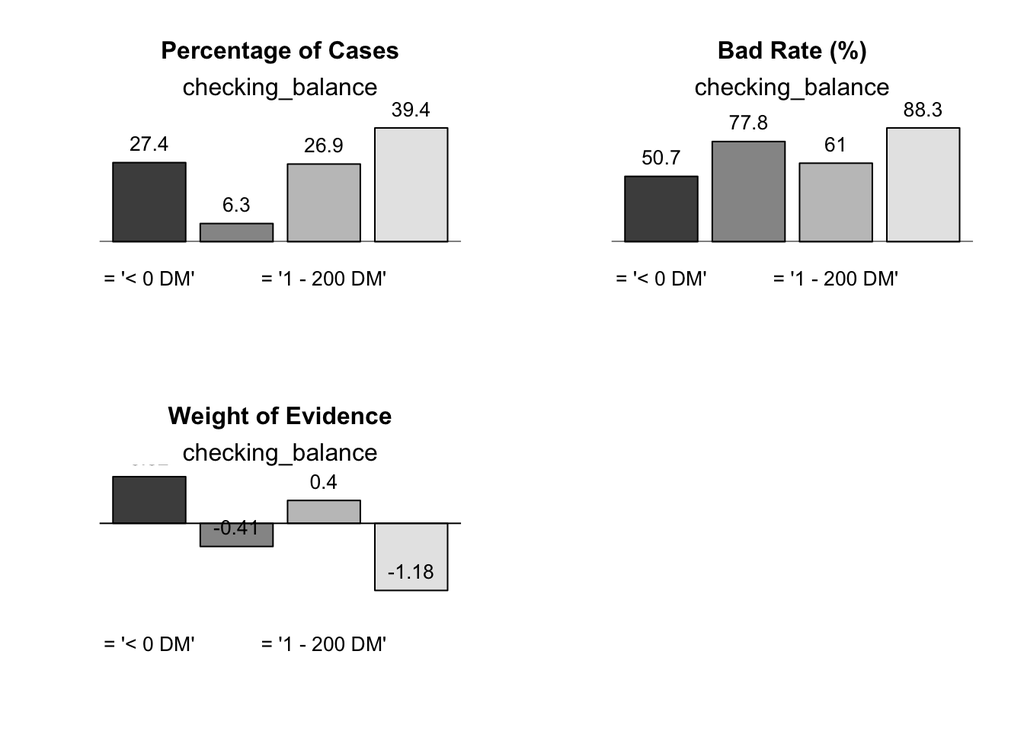

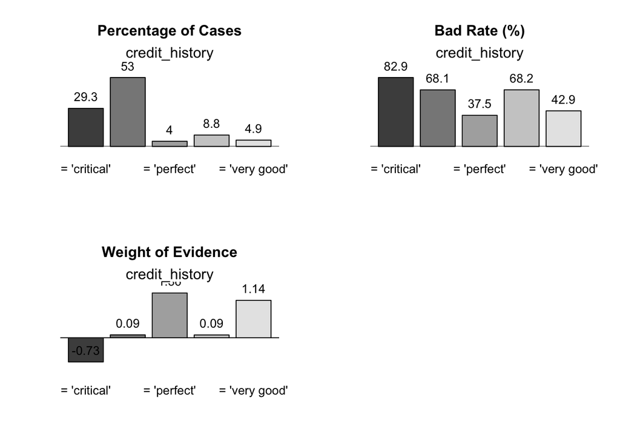

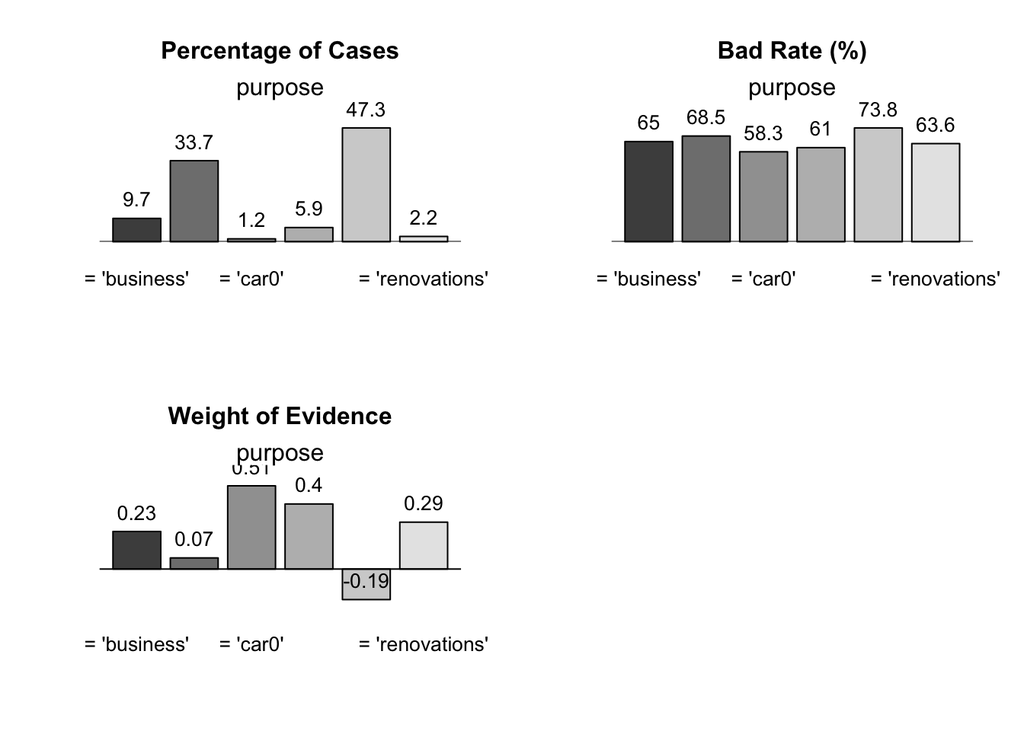

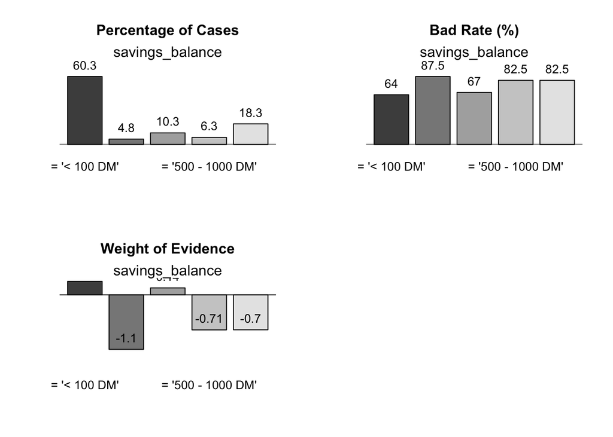

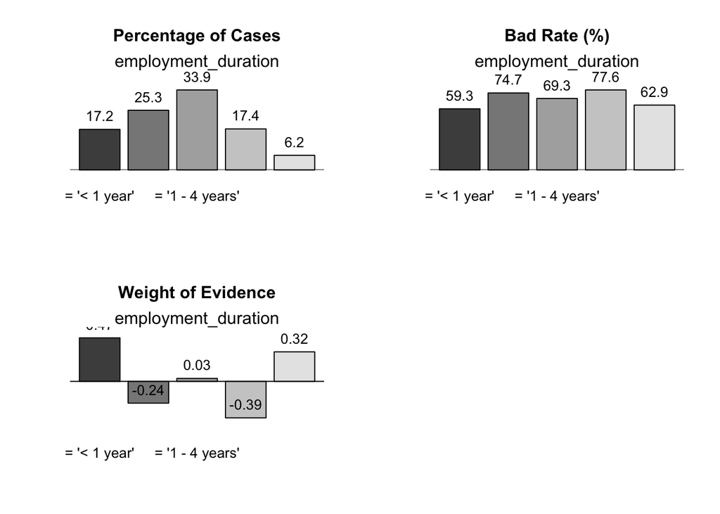

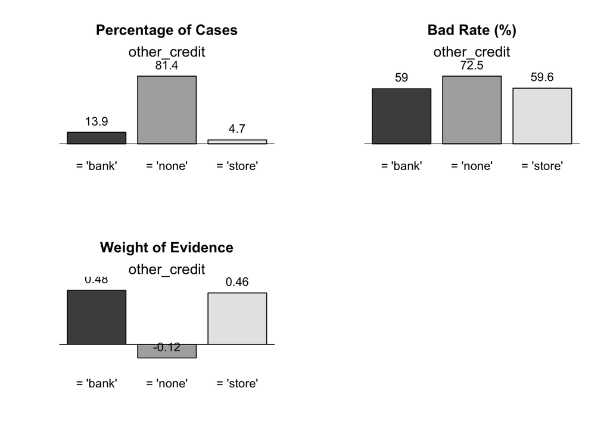

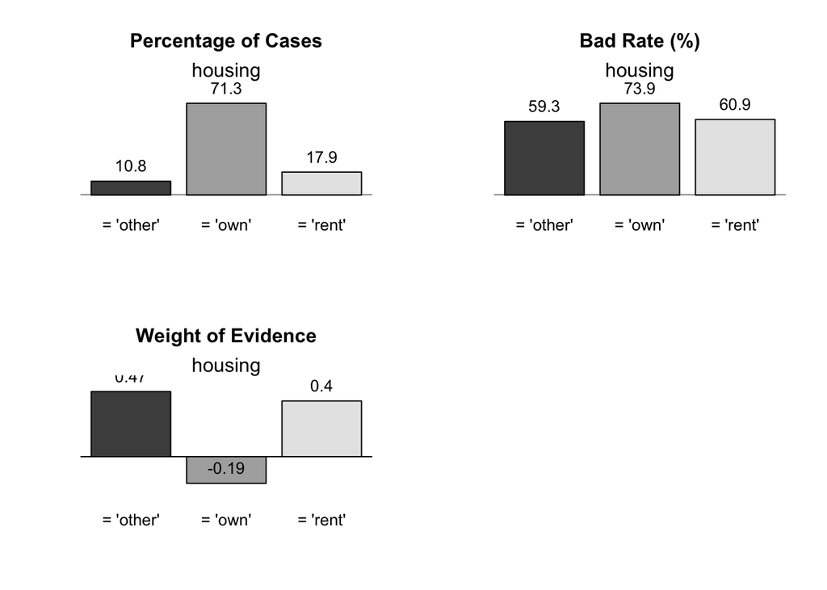

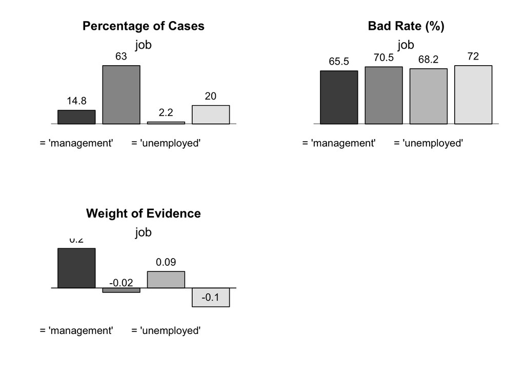

```r
for (i in names.f){

  base.f[,paste(i,"_fine", sep="")]<-base.f[,i]
  par(mfrow=c(2,2))
  results<- smbinning.factor(df=base.f, y="def_woe", x=i, maxcat=length(unique(base.f[,i])))
  smbinning.plot(results,option="dist",sub=i)
  smbinning.plot(results,option="badrate",sub=i)
  smbinning.plot(results,option="WoE",sub=i)
  IV<-rbind(IV, as.data.frame(cbind("VAR"=i, "IV"=results$ivtable[results$ivtable$Cutpoint=="Total", "IV"])))
  d<-results$ivtable[,c("Cutpoint","WoE","PctRec")]
  d<-d[d$Cutpoint!="Total",]
  d<-d[with(d, order(d$WoE)),]
  d$numer<-11:(nrow(d)+10)
  WOE[[i]]<-d


}
```

```r
dev.off()
```

## Variables quality assessment

```r
library(forcats)
library(pROC)
```

At this point we can connect data sets with numeric and factor variables.

```r
base<-cbind(base.f,base.n)[,1:32]
str(base)
```

```
## 'data.frame':    1000 obs. of  32 variables:
##  $ checking_balance         : Factor w/ 4 levels "< 0 DM","> 200 DM",..: 1 3 4 1 1 4 4 3 4 3 ...
##  $ credit_history           : Factor w/ 5 levels "critical","good",..: 1 2 1 2 4 2 2 2 2 1 ...
##  $ purpose                  : Factor w/ 6 levels "business","car",..: 5 5 4 5 2 4 5 2 5 2 ...
##  $ savings_balance          : Factor w/ 5 levels "< 100 DM","> 1000 DM",..: 5 1 1 1 1 5 4 1 2 1 ...
##  $ employment_duration      : Factor w/ 5 levels "< 1 year","> 7 years",..: 2 3 4 4 3 3 2 3 4 5 ...
##  $ other_credit             : Factor w/ 3 levels "bank","none",..: 2 2 2 2 2 2 2 2 2 2 ...
##  $ housing                  : Factor w/ 3 levels "other","own",..: 2 2 2 1 1 1 2 3 2 2 ...
##  $ job                      : Factor w/ 4 levels "management","skilled",..: 2 2 4 2 2 4 2 1 4 1 ...
##  $ phone                    : Factor w/ 2 levels "no","yes": 2 1 1 1 1 2 1 2 1 1 ...
##  $ def_woe                  : num  0 1 0 0 1 0 0 0 0 1 ...
##  $ def                      : num  1 0 1 1 0 1 1 1 1 0 ...
##  $ checking_balance_fine    : Factor w/ 4 levels "< 0 DM","> 200 DM",..: 1 3 4 1 1 4 4 3 4 3 ...
##  $ credit_history_fine      : Factor w/ 5 levels "critical","good",..: 1 2 1 2 4 2 2 2 2 1 ...
##  $ purpose_fine             : Factor w/ 6 levels "business","car",..: 5 5 4 5 2 4 5 2 5 2 ...
```

[output cut: 18 more lines]

```r
stats<-cbind(IV, Gini=NA, miss=NA)

l<-"checking_balance_fine"
```

Now we will provide us with dataset which will help us asses usefullness of particular variables.

```r
for (l in names(WOE)){

  base[,paste(l,"_fine", sep="")]<-fct_explicit_na(base[,paste(l,"_fine", sep="")], na_level="Missing")

  variable<-base[,c("def_woe", paste(l,"_fine", sep=""))]
  woe<- WOE[[l]][c("Cutpoint", "WoE")]

  if (is.character(woe$Cutpoint)==TRUE)
  {
    woe$Cutpoint<-as.factor(gsub("= '|'", "", woe$Cutpoint))
    woe$Cutpoint<-as.factor(woe$Cutpoint)
  }


  dat_temp<-merge(variable, woe, by.x=paste(l,"_fine", sep=""), by.y="Cutpoint", all.x=T)

  colnames(dat_temp)[which(names(dat_temp) == "WoE")] <- paste(l, "_woe", sep="")

  base<-merge(base, woe, by.x=paste(l,"_fine", sep=""), by.y="Cutpoint", all.x=T)
  colnames(base)[which(names(base) == "WoE")] <- paste(l, "_woe", sep="")

  print(c(any(is.na(dat_temp[,paste(l, "_woe", sep="")])), l))

  gini<- c(2*auc(dat_temp$def_woe,dat_temp[,paste(l, "_woe", sep="") ])-1)

  stats[stats$VAR==l, "Gini"]<-gini


  miss<-1-c(nrow(dat_temp[dat_temp[,paste(l,"_fine", sep="")]!='Missing', ])/nrow(dat_temp))

  stats[stats$VAR==l, "miss"]<-miss

}
```

```
## [1] "FALSE"            "checking_balance"
## [1] "FALSE"          "credit_history"
## [1] "FALSE"   "purpose"
## [1] "FALSE"           "savings_balance"
## [1] "FALSE"               "employment_duration"
## [1] "FALSE"        "other_credit"
## [1] "FALSE"   "housing"
## [1] "FALSE" "job"
## [1] "FALSE" "phone"
```

```r
write.csv(stats, "stats.csv")
```

```r
stats <- read.csv("stats.csv")

stats
```

```
##   X                 VAR     IV       Gini miss
## 1 1    checking_balance 0.6660 0.41553810    0
## 2 2      credit_history 0.2932 0.25360952    0
## 3 3             purpose 0.0384 0.10355714    0
## 4 4     savings_balance 0.1961 0.19828571    0
## 5 5 employment_duration 0.0866 0.16163810    0
## 6 6        other_credit 0.0576 0.09637143    0
## 7 7             housing 0.0833 0.13436190    0
## 8 8                 job 0.0088 0.04288571    0
## 9 9               phone 0.0064 0.03904762    0
```

As variables job and phone have IV below 0.02, we will exclude them from further analysis.

## Train and Test dataset

To have the opportunity of checkig quality of our model we have to divide our dataset int training and testing one.

```r
library(caret)

set.seed(987654321)
which_train <- createDataPartition(base$def,
                                   p = 0.7,
                                   list = FALSE)

train <- base[which_train,]
test <- base[-which_train,]
```

## Coarse classing

Now we are moving to the coarse classing phase.

```r
library(zoo)
library(lattice)
library(pROC)
library(forcats)
library(RColorBrewer)
library(smbinning)
library(devtools)
library(woe)
library(woeBinning)
library(plyr)
```

At the begeninng we will select require collumns from our dataset.

```r
columns<-colnames(train)[-which(names(train) %in% c("def","def_woe"))]
nums <- sapply(train[,columns], is.numeric)

columns.n<-columns[nums==T]
```

```r
temp<-data.frame(VAR=character(), VALUE=integer())
stats<-data.frame(VAR=character(), IV=integer(),Gini=integer(), MISS=integer(),IVw=integer(),Giniw=integer(), MISSw=integer())
```

### Cut offs for testing data

```r
cut_offs<-data.frame(VAR=character(), cuts=integer())
zmienna_c<-columns.n[1]
```

```r
pdf("WoE_coarse.pdf")
for (zmienna_c in columns.n){


  par(xpd = T, mar = par()$mar, mfrow=c(2,2))
  result<-smbinning(train[,c("def_woe", zmienna_c)], y="def_woe", x=zmienna_c, p=0.05)


  if(length(result)>1){
    points<-list(result$cuts)
    cut_offs<-rbind(cut_offs,as.data.frame(cbind("VAR"=zmienna_c,"cuts"=points)))

    IV<-result$ivtable

    train[,paste(zmienna_c, "_coarse", sep="")]<- cut(train[,zmienna_c], breaks=c(-Inf,unique(result$cuts),Inf),
                                                      labels=c(paste("<=", unique(result$cuts)),"<= Inf"),
                                                      include.lowest = T)

    train[,paste(zmienna_c, "_coarse", sep="")]<-fct_explicit_na(train[,paste(zmienna_c, "_coarse", sep="")], na_level="Missing")

    test[,paste(zmienna_c, "_coarse", sep="")]<- cut(test[,zmienna_c], breaks=c(-Inf,unique(result$cuts),Inf),
                                                     labels=c(paste("<=", unique(result$cuts)),"<= Inf"),
                                                     include.lowest = T)
    test[,paste(zmienna_c, "_coarse", sep="")]<-fct_explicit_na(test[,paste(zmienna_c, "_coarse", sep="")], na_level="Missing")


    IVw<-sum(iv.mult(test,"def",vars=paste(zmienna_c,"_coarse",sep=""))[[1]][,"miv"])
    IV$Cutpoint<-ifelse(grepl(">",IV$Cutpoint)==T,"<= Inf",IV$Cutpoint)

    train<-merge(train,IV[,c("Cutpoint", "WoE")],by.x= paste(zmienna_c, "_coarse", sep=""), by.y="Cutpoint", all.x=T, sort=F)
    colnames(train)[which(names(train) == "WoE")] <- paste(zmienna_c, "_woe", sep="")

    test<-merge(test,IV[,c("Cutpoint", "WoE")],by.x= paste(zmienna_c, "_coarse", sep=""), by.y="Cutpoint", all.x=T, sort=F)
    colnames(test)[which(names(test) == "WoE")] <- paste(zmienna_c, "_woe", sep="")


    gini<- 2*auc(train$def_woe,train[,paste(zmienna_c, "_woe", sep="") ])-1
    giniw<- 2*auc(test$def_woe,test[,paste(zmienna_c, "_woe", sep="") ])-1

    miss<-1-nrow(train[!(is.na(train[,zmienna_c])),])/nrow(train)
    missw<-1-nrow(test[!(is.na(test[,zmienna_c])),])/nrow(test)
    stats<-rbind(stats, as.data.frame(cbind("VAR"=zmienna_c, "IV"=IV[IV$Cutpoint=="Total", "IV"],"Gini"=gini,  "MISS"=miss,"IVw"=IVw, "Giniw"=giniw,  "MISSw"=missw)))


    plot<-IV[!is.na(IV$WoE) & IV$Cutpoint!="Total",]
    plot$WoE<-ifelse(plot$WoE==Inf, 8, ifelse(plot$WoE==-Inf, -8,plot$WoE))
    g<-barplot(plot$WoE,names.arg=plot$Cutpoint, cex.names=0.5, main=zmienna_c, xaxt="n")
    print(g)
    axis(1,g,plot$Cutpoint, tick=F, las=2, cex.axis=0.7)
    text(g,plot$WoE, labels=paste("WoE=",format(plot$WoE,digits=1)," \n Fill=",round(plot$PctRec,3)*100, "%", sep=""), xpd = T, col = "black", pos=3, cex=0.7)



    freq.test<-as.data.frame(table(test[,paste(zmienna_c, "_coarse", sep="")])/ nrow(test))
    colnames(freq.test)<-c("Cutpoint", "PctRec")
    freq.train<-plot[,c("Cutpoint","PctRec")]
    freq<-merge(freq.train,freq.test, all.x=T, by="Cutpoint")
    colnames(freq)<- c("Cutpoint","Train","Test")
    rownames(freq)<-freq[,1]
    freq<-freq[,-1]
    library(ggplot2)


    stacked<-barplot(as.matrix(freq), beside=F, main=zmienna_c)
    print(stacked)
    legend("topright", legend=row.names(freq), cex=0.6, bty="o",pch=21)


    smbinning.plot(result,option="dist",sub=zmienna_c)

    smbinning.plot(result,option="badrate",sub=zmienna_c)


  }


  temp<-rbind(temp, as.data.frame(cbind(VAR=zmienna_c,VALUE=length(result)>1 )))
  names(temp)<-c("VAR","VALUE")


}
```

```
## Information Value 0.34
```

```
##      [,1]
## [1,]  0.7
## [2,]  1.9
```

```
## [1] 0.7 1.9
```

```
## Information Value 0.28
```

```
##      [,1]
## [1,]  0.7
## [2,]  1.9
```

```
## [1] 0.7 1.9
```

```
## Information Value 0.04
```

```
##      [,1]
## [1,]  0.7
## [2,]  1.9
```

```
## [1] 0.7 1.9
```

```
## Information Value 0.41
```

```
##      [,1]
## [1,]  0.7
## [2,]  1.9
## [3,]  3.1
```

```
## [1] 0.7 1.9
```

```
## Information Value 0.05
```

```
##      [,1]
## [1,]  0.7
## [2,]  1.9
```

```
## [1] 0.7 1.9
```

```
## Information Value 0.06
```

```
##      [,1]
## [1,]  0.7
## [2,]  1.9
```

```
## [1] 0.7 1.9
```

```
## Information Value 0.01
```

```
##      [,1]
## [1,]  0.7
## [2,]  1.9
```

```
## [1] 0.7 1.9
```

```r
dev.off()
```

### Inspecting Factors

```r
columns.f <- c("employment_duration_coarse", "savings_balance_coarse", "credit_history_coarse",
               "amount_coarse", "months_loan_duration_coarse", "age_coarse", "amount_coarse",
               "months_loan_duration_coarse")
```

```r
zmienna_c<-columns.f[1]

resetPar <- function() {
  dev.new()
  op <- par(no.readonly = TRUE)
  dev.off()
  op
}

par(resetPar())


zmienna_c

pdf("WoE_coarse_fact.pdf")
for (zmienna_c in columns.f){


  par(xpd = T, mfrow=c(2,2))

  result<-smbinning.factor(train[,c("def_woe", zmienna_c)], y="def_woe", x=zmienna_c)


  if(length(result)>1){
    points<-list(result$cuts)
    cut_offs<-rbind(cut_offs,as.data.frame(cbind("VAR"=zmienna_c,"cuts"=points)))

    IV<-result$ivtable


    train[,zmienna_c]<-fct_explicit_na(train[,zmienna_c], na_level="Missing")
    test[,zmienna_c]<-fct_explicit_na(test[,zmienna_c], na_level="Missing")


    IVw<-sum(iv.mult(test,"def",vars=zmienna_c)[[1]][,"miv"])
    IV$Cutpoint<-as.factor(gsub("= |'","",IV$Cutpoint))


    train<-merge(train,IV[,c("Cutpoint", "WoE")],by.x= zmienna_c, by.y="Cutpoint", all.x=T, sort=F)
    colnames(train)[which(names(train) == "WoE")] <- gsub("_coarse","_woe",zmienna_c)

    test<-merge(test,IV[,c("Cutpoint", "WoE")],by.x= zmienna_c, by.y="Cutpoint", all.x=T, sort=F)
    colnames(test)[which(names(test) == "WoE")] <- gsub("_coarse","_woe",zmienna_c)

    gini<- 2*auc(train$def_woe,train[,gsub("_coarse","_woe",zmienna_c) ])-1
    giniw<- 2*auc(test$def_woe,test[,gsub("_coarse","_woe",zmienna_c)])-1

    miss<-1-nrow(train[!(is.na(train[,zmienna_c])),])/nrow(train)
    missw<-1-nrow(test[!(is.na(test[,zmienna_c])),])/nrow(test)
    stats<-rbind(stats, as.data.frame(cbind("VAR"=zmienna_c, "IV"=IV[IV$Cutpoint=="Total", "IV"],"Gini"=gini,  "MISS"=miss,"IVw"=IVw, "Giniw"=giniw,  "MISSw"=missw)))


    plot<-IV[!is.na(IV$WoE) & IV$Cutpoint!="Total",]
    plot$WoE<-ifelse(plot$WoE==Inf, 8, ifelse(plot$WoE==-Inf, -8,plot$WoE))
    g<-barplot(plot$WoE,names.arg=plot$Cutpoint, cex.names=0.5, main=zmienna_c, xaxt="n")
    print(g)
    axis(1,g,plot$Cutpoint, tick=F, las=2, cex.axis=0.7)
    text(g,plot$WoE, labels=paste("WoE=",format(plot$WoE,digits=1)," \n Fill=",round(plot$PctRec,3)*100, "%", sep=""), xpd = T, col = "black", pos=3, cex=0.7)



    freq.test<-as.data.frame(table(test[,zmienna_c])/ nrow(test))
    colnames(freq.test)<-c("Cutpoint", "PctRec")
    freq.train<-plot[,c("Cutpoint","PctRec")]
    freq<-merge(freq.train,freq.test, all.x=T, by="Cutpoint")
    colnames(freq)<- c("Cutpoint","Train","Test")
    rownames(freq)<-freq[,1]
    freq<-freq[,-1]

    stacked<-barplot(as.matrix(freq), beside=F, main=zmienna_c)
    print(stacked)



    smbinning.plot(result,option="dist",sub=zmienna_c)

    smbinning.plot(result,option="badrate",sub=zmienna_c)


  }

  temp<-rbind(temp, as.data.frame(cbind(VAR=zmienna_c,VALUE=length(result)>1 )))
  names(temp)<-c("VAR","VALUE")


}

dev.off()
warnings()
```

```r
write.csv(stats, file="stats.csv")
save(train,file="trainm")
save(test,file="testm")
```

## Correlation analysis

Now we will conduct correlation analysis on variables ending with `_woe`

```r
var_to_check<-colnames(train)[grep("_woe", colnames(train))]
```

As `def_woe` is our target variable we have to exclude it.

```r
var_to_check<-var_to_check[-1]
base_kor<-train[,var_to_check]


load(file="kendall2.RData")
```

```r
library(pcaPP)
tim <- proc.time ()[1]
kendall2 <-cor.fk (base_kor)
cat ("cor runtime [s]:", proc.time ()[1] - tim, "(n =", nrow (base_kor), ")\n")
```

```
## cor runtime [s]: 0.03 (n = 700 )
```

```r
save(kendall2,file="kendall2.RData")

View(kendall2)
```

## Modelling

We have to load necessary libraries.

```r
library(LogisticDx)
library(pROC)
library(gtools)

cols<-colnames(train)[grep("woe", colnames(train))]
```

### Logistic regression

To use logistic regression model we have to prepare our data.

```r
cols<-cols[-grep("def_woe", cols)]
data<-train[,c("def",cols)]
```

### model with constant only

```r
baza<-glm(def ~ 1,data=data, family=binomial("logit"))
summary(baza)
```

```
##
## Call:
## glm(formula = def ~ 1, family = binomial("logit"), data = data)
##
## Deviance Residuals:
##     Min       1Q   Median       3Q      Max
## -1.5456  -1.5456   0.8494   0.8494   0.8494
##
## Coefficients:
##             Estimate Std. Error z value            Pr(>|z|)
## (Intercept)  0.83373    0.08226   10.14 <0.0000000000000002 ***
## ---
## Signif. codes:  0 '***' 0.001 '**' 0.01 '*' 0.05 '.' 0.1 ' ' 1
##
## (Dispersion parameter for binomial family taken to be 1)
##
##     Null deviance: 858.57  on 699  degrees of freedom
## Residual deviance: 858.57  on 699  degrees of freedom
## AIC: 860.57
##
## Number of Fisher Scoring iterations: 4
```

constant -> expected value for a base group -> whole sample

```r
mean(train$def)
```

```
## [1] 0.6971429
```

```r
model1<-glm(def ~ months_loan_duration_woe + amount_woe + credit_history_woe + savings_balance_woe +
              employment_duration_woe,data=data, family=binomial("logit"))
summary(model1)
```

```
##
## Call:
## glm(formula = def ~ months_loan_duration_woe + amount_woe + credit_history_woe +
##     savings_balance_woe + employment_duration_woe, family = binomial("logit"),
##     data = data)
##
## Deviance Residuals:
##     Min       1Q   Median       3Q      Max
## -2.6519  -1.0924   0.5652   0.8534   1.8546
##
## Coefficients:
##                          Estimate Std. Error z value             Pr(>|z|)
## (Intercept)               0.84670    0.09027   9.379 < 0.0000000000000002
## months_loan_duration_woe -0.96514    0.28429  -3.395             0.000686
## amount_woe               -0.70894    0.41388  -1.713             0.086730
## credit_history_woe       -0.83993    0.16459  -5.103         0.0000003340
## savings_balance_woe      -1.26481    0.22670  -5.579         0.0000000242
## employment_duration_woe  -0.89751    0.29663  -3.026             0.002481
##
## (Intercept)              ***
## months_loan_duration_woe ***
## amount_woe               .
## credit_history_woe       ***
## savings_balance_woe      ***
## employment_duration_woe  **
## ---
## Signif. codes:  0 '***' 0.001 '**' 0.01 '*' 0.05 '.' 0.1 ' ' 1
##
## (Dispersion parameter for binomial family taken to be 1)
##
##     Null deviance: 858.57  on 699  degrees of freedom
## Residual deviance: 759.64  on 694  degrees of freedom
## AIC: 771.64
##
## Number of Fisher Scoring iterations: 4
```

```r
model2  <- glm(def ~ months_loan_duration_woe + credit_history_woe + employment_duration_woe,
              data=data, family=binomial("logit"))


joinSignif <- function(model1, model2){
  ano <- anova(model1, model2, test="LRT")
  pval <- ano$`Pr(>Chi)`[2]
  print(ano)
  return(pval <= 0.05) # if null can be rejected
}

logit <- joinSignif(model1,model2)
```

```
## Analysis of Deviance Table
##
## Model 1: def ~ months_loan_duration_woe + amount_woe + credit_history_woe +
##     savings_balance_woe + employment_duration_woe
## Model 2: def ~ months_loan_duration_woe + credit_history_woe + employment_duration_woe
##   Resid. Df Resid. Dev Df Deviance       Pr(>Chi)
## 1       694     759.64
## 2       696     798.85 -2  -39.208 0.000000003063 ***
## ---
## Signif. codes:  0 '***' 0.001 '**' 0.01 '*' 0.05 '.' 0.1 ' ' 1
```

Reject hypothesis, that removed insignificant variables are jointly insignificant (p-value <0.05)

Then we need regect them one by one -> general to specific approach

```r
model3  <- glm(def ~ months_loan_duration_woe + credit_history_woe + savings_balance_woe +
                 employment_duration_woe,
               data=data, family=binomial("logit"))

summary(model3)  #OK
```

```
##
## Call:
## glm(formula = def ~ months_loan_duration_woe + credit_history_woe +
##     savings_balance_woe + employment_duration_woe, family = binomial("logit"),
##     data = data)
##
## Deviance Residuals:
##     Min       1Q   Median       3Q      Max
## -2.6451  -1.0700   0.5744   0.8552   1.7816
##
## Coefficients:
##                          Estimate Std. Error z value             Pr(>|z|)
## (Intercept)               0.84669    0.09002   9.406 < 0.0000000000000002
## months_loan_duration_woe -1.05377    0.27911  -3.775              0.00016
## credit_history_woe       -0.86656    0.16360  -5.297         0.0000001178
## savings_balance_woe      -1.24287    0.22443  -5.538         0.0000000306
## employment_duration_woe  -0.87812    0.29551  -2.972              0.00296
##
## (Intercept)              ***
## months_loan_duration_woe ***
## credit_history_woe       ***
## savings_balance_woe      ***
## employment_duration_woe  **
## ---
## Signif. codes:  0 '***' 0.001 '**' 0.01 '*' 0.05 '.' 0.1 ' ' 1
##
## (Dispersion parameter for binomial family taken to be 1)
##
##     Null deviance: 858.57  on 699  degrees of freedom
## Residual deviance: 762.55  on 695  degrees of freedom
## AIC: 772.55
##
## Number of Fisher Scoring iterations: 4
```

```r
logit <- joinSignif(model1,model3)
```

```
## Analysis of Deviance Table
##
## Model 1: def ~ months_loan_duration_woe + amount_woe + credit_history_woe +
##     savings_balance_woe + employment_duration_woe
## Model 2: def ~ months_loan_duration_woe + credit_history_woe + savings_balance_woe +
##     employment_duration_woe
##   Resid. Df Resid. Dev Df Deviance Pr(>Chi)
## 1       694     759.64
## 2       695     762.55 -1  -2.9051   0.0883 .
## ---
## Signif. codes:  0 '***' 0.001 '**' 0.01 '*' 0.05 '.' 0.1 ' ' 1
```

```r
library(jtools)
library(ggstance)
```

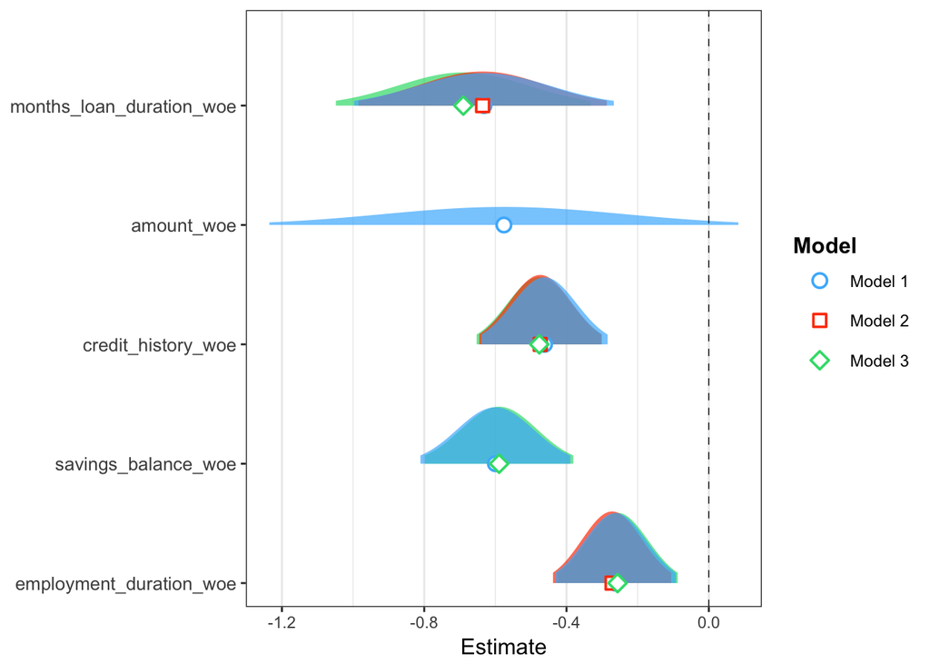

```r
plot_summs(model1, model2, model3,  scale = TRUE, plot.distributions = TRUE)
```

## Quality Assesment

Functions needed for quality assessment

```r
hosmerlem = function(y, yhat, g=20) {
  cutyhat = cut(yhat,breaks = quantile(yhat, probs=seq(0,1, 1/g)), include.lowest=TRUE)
  obs = xtabs(cbind(1 - y, y) ~ cutyhat)
  expect = xtabs(cbind(1 - yhat, yhat) ~ cutyhat)
  chisq = sum((obs - expect)^2/expect)
  P = 1 - pchisq(chisq, g - 2)
  return(list(chisq=chisq,p.value=P))
  hr=P
}

cal_psi <- function(data1,data2, bench, target, bin)
{
  ben<-sort(data1[,bench]);
  tar<-sort(data2[,target]);
  # get and sort benchmark and target variable
  ttl_bench<-length(ben);
  ttl_target<-length(tar);
  # get total num obs for benchmark and target
  n<-ttl_bench%/%bin; #Num of obs per bin
  psi_bin<-rep(0,times=bin) #initialize PSI=0 for each bin

  for (i in 1:bin) # calculate PSI for ith bin
  {

    lower_cut<-ben[(i-1)*n+1];
    if(i!=bin){upper_cut<-ben[(i-1)*n+n]; pct_ben<-n/ttl_bench;} else
    {upper_cut<-ben[ttl_bench];
    pct_ben<(ttl_bench-n*(bin-1))/ttl_bench;}
    #last bin should have all remaining obs

    pct_tar<-length(tar[tar>lower_cut&tar<=upper_cut])/ttl_target;
    psi_bin[i]<-(pct_tar-pct_ben)*log(pct_tar/pct_ben);
  }
  psi<-sum(psi_bin);
  return(psi);
}
```

```r
cal_psi_zm <- function(data1,data2, bench, target)
{
  ben<-sort(data1[,bench]);
  tar<-sort(data2[,target]);
  bin<-length(unique(ben))
  bin_tar<-length(unique(tar))
  # get and sort benchmark and target variable
  ttl_bench<-length(ben);
  ttl_target<-length(tar);
  # get total num obs for benchmark and target
  tab_ben<-table(ben)
  pct_ben<-tab_ben/ttl_bench
  names<-names(tab_ben)
  tab_tar<-table(tar)

  if (ttl_target!=ttl_bench) {
    tab_tar<-smartbind(tab_ben,tab_tar)
    tab_tar<-tab_tar[2,]
    tab_tar[,is.na(tab_tar)]<-0
  }
  pct_tar<-tab_tar/ttl_target
  psi_bin<-rep(0,times=bin) #initialize PSI=0 for each bin

  psi_bin<-(pct_tar-pct_ben)*log(pct_tar/pct_ben);
  psi<-sum(psi_bin);
  return(psi);
}
```

### GOF - completely basic

assumption we compare the obtained model with the “ideal” models and check whether the obtained MLV is statistically close to 0

H0: the model is well fitted to the data

```r
gf<-pchisq(model3$deviance, model3$df.residual,lower.tail = F)
```

```r
gf
```

```
## [1] 0.09256214
```

Conclusion: p-value = 0.09256214 > 0.05 -> Fail to reject the null, that model is well fitted to the data.

It’s good, we want it.

## LR test on the significance of variables

we check if the maxW for the model is significantly larger than for the model only with the constant - test for the total significance of the model

H0 variables are statistically irrelevant

```r
ist<-pchisq(model3$null.deviance-model3$deviance, model3$df.null-model3$df.residual,lower.tail = F)
ist
```

```
## [1] 0.00000000000000000006903432
```

Conclusion: p-value < 0.05 -> Reject the null, that variables are statistically irrelevant.

They are statistically relevant.

## Hosmera - Lemeshowa test

H0: the model is well fitted to the data

has many disadvantages - first of all it is very sensitive to the number of buckets

```r
hr<-hosmerlem(y=data$def, yhat=fitted(model1),g=10)
hr$p.value
```

```
## [1] 0.6089546
```

Conclusion: p-value > 0.05 -> Fail to reject the null, that the model is well fitted to the data. It is.

[output not shown]

[output not shown]

[output not shown]

[figure not shown]

```r
#assaigning PD to data
  # fitted.values - PD
  # linear.predictors - ln(p/(1-p))

data$baza<-baza$fitted.values
data$model<-model$fitted.values
```

```r
max<-glm(def ~ .,data=data, family=binomial("logit"))
data$max<-max$fitted.values


# scaling PD to assumed scale
  # 660 points means ODDS = 72 and ODDS double for 40 points
```

```r
data$score<-(660-40/log(1/2)*log(1/72))+40/log(1/2)*model$linear.predictors
```

```r
# assaignig PD & SCORE
test$model<-predict(model, newdata=test, type="response")
test$score<-(660-40/log(1/2)*log(1/72))+40/log(1/2)*predict(model, newdata=test, type="link")

train$model<-predict(model, newdata=train, type="response")
train$score<-(660-40/log(1/2)*log(1/72))+40/log(1/2)*predict(model, newdata=train, type="link")

#test roc - checking wheter ROC cure is significanlty better
#H0  ROC curves are equally good
roc_test_baza<-roc.test(data$def, data$model, data$baza,method="d")$p.value
roc_test_og<-roc.test(data$def, data$max, data$model,method="d")$p.value
# conclusions?
```

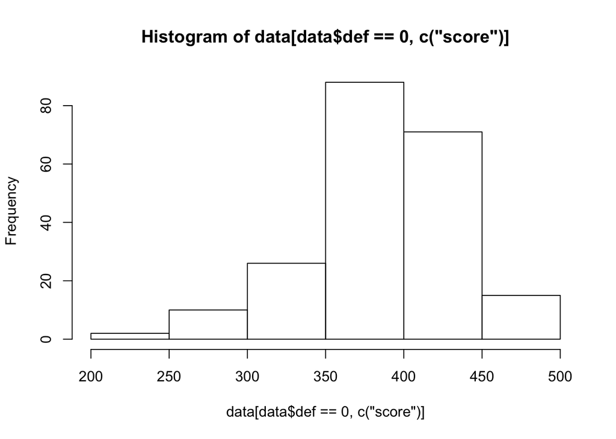

```r
# mg<-mean(data[data$def==0,c("score")])
# mb<-mean(data[data$def==1,c("score")])
# vg<-var(data[data$def==0,c("score")])
# vb<-var(data[data$def==1,c("score")])
# ng<-length(data[data$def==0,c("score")])
# nb<-length(data[data$def==1,c("score")])
# n<-ng+nb
# s<-sqrt(((ng-1)*vg+(nb-1)*vb)/(n-2))
#
# u<-mg-mb+qt(0.975,n-2)*s*sqrt(1/ng+1/nb)
# l<-mg-mb-qt(0.975,n-2)*s*sqrt(1/ng+1/nb)
#
# g<-2*pnorm((mg-mb)/(s*sqrt(2)))-1
# gu<-2*pnorm(u/(s*sqrt(2)))-1
# gl<-2*pnorm(l/(s*sqrt(2)))-1
#mean(data[data$def==0,c("model")])
#mean(data[data$def==1,c("model")])

hist(data[data$def==0,c("score")])
```

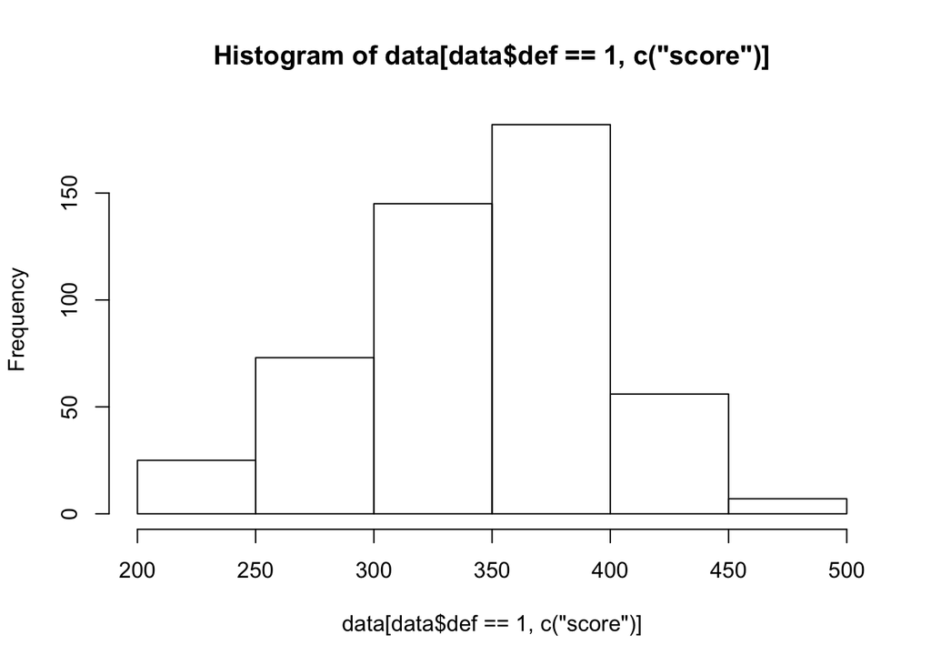

[output not shown]

```r
hist(data[data$def==1,c("score")])
```

## Creating model using neural network

In this section we will create model using neural network without adjusting to see how it will work comparing to the adjusted logistic regression model.  
we will start with loading libraries.

```r
# Load libraries
library(keras)
library(lime)
library(tidyquant)
library(rsample)
library(recipes)
library(yardstick)
library(corrr)
library(readr)
```

```r
def_data_tbl <- credit %>%
  drop_na() %>%
  select(default, everything())

sum(def_data_tbl$checking_balance=="unknown" | def_data_tbl$savings_balance == "unknown")
```

```
## [1] 478
```

```r
glimpse(def_data_tbl)
```

```
## Observations: 1,000
## Variables: 17
## $ default              <fct> no, yes, no, no, yes, no, no, no, no, yes...
## $ checking_balance     <fct> < 0 DM, 1 - 200 DM, unknown, < 0 DM, < 0 ...
## $ months_loan_duration <dbl> 6, 48, 12, 42, 24, 36, 24, 36, 12, 30, 12...
## $ credit_history       <fct> critical, good, critical, good, poor, goo...
## $ purpose              <fct> furniture/appliances, furniture/appliance...
## $ amount               <dbl> 1169, 5951, 2096, 7882, 4870, 9055, 2835,...
## $ savings_balance      <fct> unknown, < 100 DM, < 100 DM, < 100 DM, < ...
## $ employment_duration  <fct> > 7 years, 1 - 4 years, 4 - 7 years, 4 - ...
## $ percent_of_income    <dbl> 4, 2, 2, 2, 3, 2, 3, 2, 2, 4, 3, 3, 1, 4,...
## $ years_at_residence   <dbl> 4, 2, 3, 4, 4, 4, 4, 2, 4, 2, 1, 4, 1, 4,...
## $ age                  <dbl> 67, 22, 49, 45, 53, 35, 53, 35, 61, 28, 2...
## $ other_credit         <fct> none, none, none, none, none, none, none,...
## $ housing              <fct> own, own, own, other, other, other, own, ...
## $ existing_loans_count <dbl> 2, 1, 1, 1, 2, 1, 1, 1, 1, 2, 1, 1, 1, 2,...
## $ job                  <fct> skilled, skilled, unskilled, skilled, ski...
## $ dependents           <dbl> 1, 1, 2, 2, 2, 2, 1, 1, 1, 1, 1, 1, 1, 1,...
## $ phone                <fct> yes, no, no, no, no, yes, no, yes, no, no...
```

We will divide set into trainnig and testinng set.

```r
set.seed(100)
def_train_test_split <- initial_split(def_data_tbl, prop = 0.8)
def_train_test_split
```

```
## <801/199/1000>
```

```r
def_train_tbl <- training(def_train_test_split)
def_test_tbl  <- testing(def_train_test_split)



def_train_tbl %>%
  select(default, amount) %>%
  mutate(
    default = default %>% as.factor() %>% as.numeric(),
    LogAmount = log(amount)
  ) %>%
  correlate() %>%
  focus(default) %>%
  fashion()
```

```
##     rowname default
## 1    amount     .15
## 2 LogAmount     .11
```

Now we have to create a recepie.

```r
def_rec_obj <- recipe(default ~ ., data = def_train_tbl) %>%
  step_discretize(months_loan_duration, options = list(cuts = 5)) %>%
  step_discretize(age, options = list(cuts = 6)) %>%
  step_dummy(all_nominal(), -all_outcomes()) %>%
  step_center(all_predictors(), -all_outcomes()) %>%
  step_scale(all_predictors(), -all_outcomes()) %>%
  prep(data = train_tbl)

def_rec_obj
```

```
## Data Recipe
##
## Inputs:
##
##       role #variables
##    outcome          1
##  predictor         16
##
## Training data contained 801 data points and no missing data.
##
## Operations:
##
## Dummy variables from months_loan_duration [trained]
## Dummy variables from age [trained]
## Dummy variables from checking_balance, credit_history, ... [trained]
## Centering for months_loan_duration, ... [trained]
## Scaling for months_loan_duration, ... [trained]
```

```r
def_x_train_tbl <- bake(def_rec_obj, newdata = def_train_tbl)
def_x_test_tbl  <- bake(def_rec_obj, newdata = def_test_tbl)



def_y_train_vec <- ifelse(pull(def_train_tbl, default) == "yes", 1, 0)
def_y_test_vec  <- ifelse(pull(def_test_tbl, default) == "yes", 1, 0)

def_x_train_tbl$default <- NULL
def_x_test_tbl$default <- NULL
```

Finally we can create a model.

```r
def_model_keras <- keras_model_sequential()


def_model_keras %>%
  # First hidden layer
  layer_dense(
    units              = 16,
    kernel_initializer = "uniform",
    activation         = "relu",
    input_shape        = ncol(def_x_train_tbl)) %>%
  # Dropout to prevent overfitting
  layer_dropout(rate = 0.1) %>%
  # Second hidden layer
  layer_dense(
    units              = 16,
    kernel_initializer = "uniform",
    activation         = "relu") %>%
  # Dropout to prevent overfitting
  layer_dropout(rate = 0.1) %>%
  # Output layer
  layer_dense(
    units              = 1,
    kernel_initializer = "uniform",
    activation         = "sigmoid") %>%
  # Compile ANN
  compile(
    optimizer = 'adam',
    loss      = 'binary_crossentropy',
    metrics   = c('accuracy')
  )

def_model_keras
```

```
## Model
## ___________________________________________________________________________
## Layer (type)                     Output Shape                  Param #
## ===========================================================================
## dense_1 (Dense)                  (None, 16)                    576
## ___________________________________________________________________________
## dropout_1 (Dropout)              (None, 16)                    0
## ___________________________________________________________________________
## dense_2 (Dense)                  (None, 16)                    272
## ___________________________________________________________________________
## dropout_2 (Dropout)              (None, 16)                    0
## ___________________________________________________________________________
## dense_3 (Dense)                  (None, 1)                     17
## ===========================================================================
## Total params: 865
## Trainable params: 865
## Non-trainable params: 0
## ___________________________________________________________________________
```

Next step is trainnig it.

```r
def_fit_keras <- fit(
  object           = def_model_keras,
  x                = as.matrix(def_x_train_tbl),
  y                = def_y_train_vec,
  batch_size       = 50,
  epochs           = 25,
  validation_split = 0.30
)


def_fit_keras
```

```
## Trained on 560 samples, validated on 241 samples (batch_size=50, epochs=25)
## Final epoch (plot to see history):
##      acc: 0.8018
##     loss: 0.4205
##  val_acc: 0.7469
## val_loss: 0.4921
```

We can plot the training/validation history of our model.

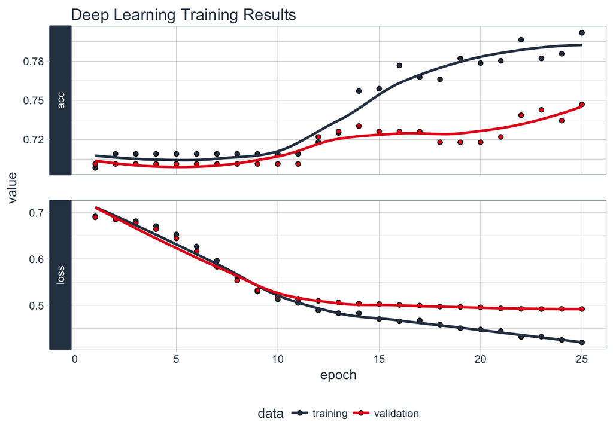

```r
plot(def_fit_keras) +
  theme_tq() +
  scale_color_tq() +
  scale_fill_tq() +
  labs(title = "Deep Learning Training Results")
```

```r
# Predicted Class Probability
def_yhat_keras_prob_vec  <- predict_proba(object = def_model_keras, x = as.matrix(def_x_test_tbl)) %>%
  as.vector()

def_estimates_keras_tbl <- tibble(
  truth      = as.factor(def_y_test_vec) %>% fct_recode(yes = "1", no = "0"),
  estimate   = as.factor(def_yhat_keras_class_vec) %>% fct_recode(yes = "1", no = "0"),
  class_prob = def_yhat_keras_prob_vec
)

def_estimates_keras_tbl
```

```
## # A tibble: 199 x 3
##    truth estimate class_prob
##    <fct> <fct>         <dbl>
##  1 yes   yes         0.553
##  2 yes   no          0.174
##  3 no    no          0.00891
##  4 no    no          0.121
##  5 no    no          0.0186
##  6 no    no          0.0652
##  7 no    no          0.0101
##  8 no    no          0.325
##  9 no    no          0.419
## 10 yes   no          0.183
## # ... with 189 more rows
```

```r
options(yardstick.event_first = FALSE) # the default is to classify 0 as the positive class instead of 1.
```

### Confusion Table

```r
def_estimates_keras_tbl %>% conf_mat(truth, estimate)
```

```
##           Truth
## Prediction  no yes
##        no  124  51
##        yes  10  14
```

### Accuracy

We can use the metrics() function to get an accuracy measurement from the test set.

```r
def_estimates_keras_tbl %>% metrics(truth, estimate)
```

```
## # A tibble: 1 x 1
##   accuracy
##      <dbl>
## 1    0.693
```

### Area Under Curve

```r
def_estimates_keras_tbl %>% roc_auc(truth, class_prob)
```

```
## [1] 0.7501722
```

### Precision and recall

```r
tibble(
  precision = def_estimates_keras_tbl %>% precision(truth, estimate),
  recall    = def_estimates_keras_tbl %>% recall(truth, estimate)
)
```

```
## # A tibble: 1 x 2
##   precision recall
##       <dbl>  <dbl>
## 1     0.583  0.215
```

As we can see area under curve using Neural Network model is slightly better than using regression model.

```r
# F1 SCORE

def_estimates_keras_tbl %>% f_meas(truth, estimate, beta = 1)
```

```
## [1] 0.3146067
```

```r
# EXPLAIN THE MODEL WITH LIME

class(def_model_keras)
```

```
## [1] "keras.engine.sequential.Sequential"
## [2] "keras.engine.training.Model"
## [3] "keras.engine.network.Network"
## [4] "keras.engine.base_layer.Layer"
## [5] "python.builtin.object"
```

```r
# Setup lime::model_type() function for keras
model_type.keras.models.Sequential <- function(x, ...) {
  return("classification")
}


# Setup lime::predict_model() function for keras
predict_model.keras.models.Sequential <- function(x, newdata, type, ...) {
  pred <- predict_proba(object = x, x = as.matrix(newdata))
  return(data.frame(Yes = pred, No = 1 - pred))
}
```

```r
# Test our predict_model() function
predict_model(x = def_model_keras, newdata = def_x_test_tbl, type = 'raw') %>%
  tibble::as_tibble()

# Run lime() on training set
def_explainer <- lime::lime(
  x              = def_x_train_tbl,
  model          = def_model_keras,
  bin_continuous = FALSE)

# Run explain() on explainer
def_explanation <- lime::explain(
  def_x_test_tbl[1:10,],
  explainer    = def_explainer,
  n_labels     = 1,
  n_features   = 4,
  kernel_width = 0.5)
```

We can inspect how each variable affect the prediction.

```r
# Feature correlations to default
def_corrr_analysis <- def_x_train_tbl %>%
  mutate(default = def_y_train_vec) %>%
  correlate() %>%
  focus(default) %>%
  rename(feature = rowname) %>%
  arrange(abs(default)) %>%
  mutate(feature = as_factor(feature))
```

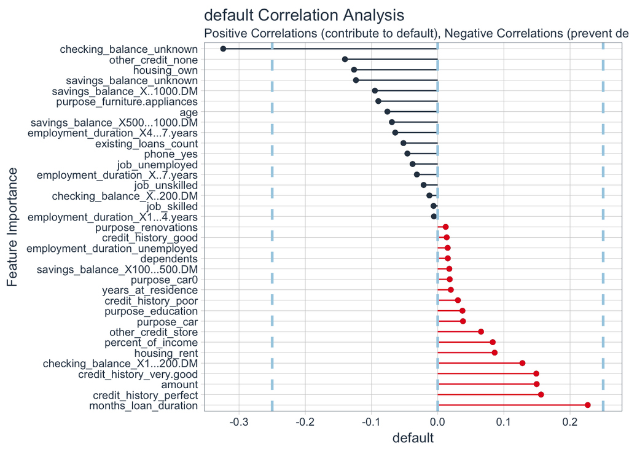

```r
def_corrr_analysis %>%
  ggplot(aes(x = default, y = fct_reorder(feature, desc(default)))) +
  geom_point() +
  # Positive Correlations - Contribute to default
  geom_segment(aes(xend = 0, yend = feature),
               color = palette_light()[[2]],
               data = def_corrr_analysis %>% filter(default > 0)) +
  geom_point(color = palette_light()[[2]],
             data = def_corrr_analysis %>% filter(default > 0)) +
  # Negative Correlations - Prevent default
  geom_segment(aes(xend = 0, yend = feature),
               color = palette_light()[[1]],
               data = def_corrr_analysis %>% filter(default < 0)) +
  geom_point(color = palette_light()[[1]],
             data = def_corrr_analysis %>% filter(default < 0)) +
  # Vertical lines
  geom_vline(xintercept = 0, color = palette_light()[[5]], size = 1, linetype = 2) +
  geom_vline(xintercept = -0.25, color = palette_light()[[5]], size = 1, linetype = 2) +
  geom_vline(xintercept = 0.25, color = palette_light()[[5]], size = 1, linetype = 2) +
  # Aesthetics
  theme_tq() +
  labs(title = "default Correlation Analysis",
       subtitle = "Positive Correlations (contribute to default), Negative Correlations (prevent default)",
       y = "Feature Importance")
```

As we can see results not necessairly go with common sense, but they give better results. It is hard to say if it is just a fallacy of the population sample or it can be explained.